# The Labour Supply Impact of Moving from Part-Time to Full-Time Subsidised Childcare

2023-07-07

## What Am I Looking At?

### The Summary

- Specifically at childcare costs and how they broadly impact the labour market.
- First chapter aims to look at specific policy reforms and how individual and household labour supply change in response.
- I use a 2017 policy change in England that expands free entitlement of childcare for working parents from 15 hours per week to 30 hours per week.
- Deploy a difference-in-difference empirical strategy to assess various labour supply responses (intensive and extensive).
- Exploit age of eligibility variation arising from the policy design.
- Mixed with matching methods to create control group from similar parents who miss out due to eligibility cutoffs.
- Tentative (very tentative) early results suggest no impact.

## Importance, i.e. Why Should You Care (About Childcare)

### Policy Relevance

- Fair to say that childcare one of the most important domestic policy areas in UK at the moment.
- Government: Major childcare-related announcements in the Spring Statement received top billing from government press releases: announcing a ‘childcare revolution’.
- Forms part of a broader worry around labour market tightness and sluggish employment rate recovery from Covid-19.
- Additional concerns around gendered economic outcomes for mothers returning to labour market after childbirth.

[figure not shown]

## Importance, i.e. Why Should You Care (About Childcare)

### Media Relevance

- Government response preceded by increasing concern from the media.
- Numerous reports from both tabloid and broadsheets highlighting impacts of increasing costs.
- Typically framed around labour shortage issues - but again, accompanied by heavy emphasis on gendered outcomes.
- Less frequently framed around business-side issues (e.g. less diverse, less dynamic composition of workforce due to gendered outcomes)

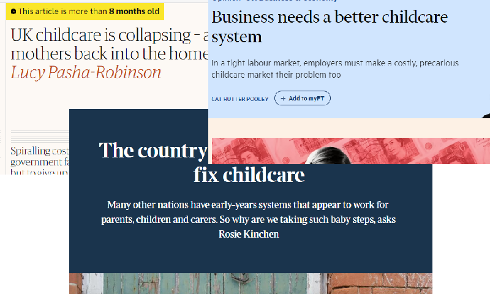

## Importance, i.e. Why Should You Care (About Childcare)

### Public Relevance

- Ultimately the policy response from government and media is simply serving an existing public interest.
- Google Trends search data for the topic ‘childcare’ (rather than a simple search term) shows it at its highest level since 2004.
- It has been visibly trending upwards consistently year-on-year since 2015.

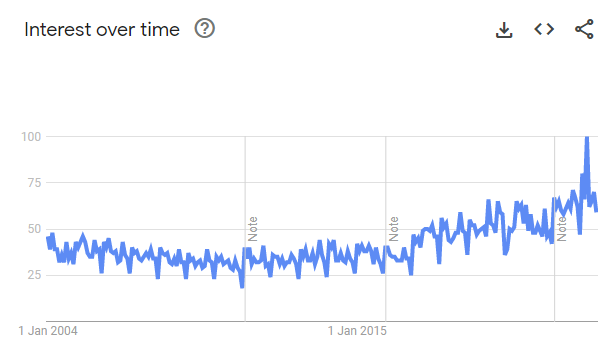

## Background & Context

### UK Childcare Prices in Context

- All measures of response often said to be driven by high prices for childcare. But just how high are they?
- UK faces some of the highest in the OECD. Particularly for couples (3rd highest).

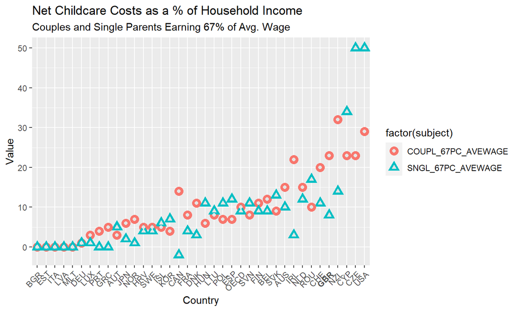

## Background & Context

### Prices Over Time

- Despite trending downwards across the OECD since 2004, UK has stayed constant.
- Chart (right) shows the evolution of prices over time for households.
- UK in red, OECD in blue.
- In fact, the lowest level recorded in 2008, and has increased somewhat since then.
- OECD value has declined from 16% of household income in 2004 to 10% in 2022.
- UK declined from 26% to 23% over same time period.

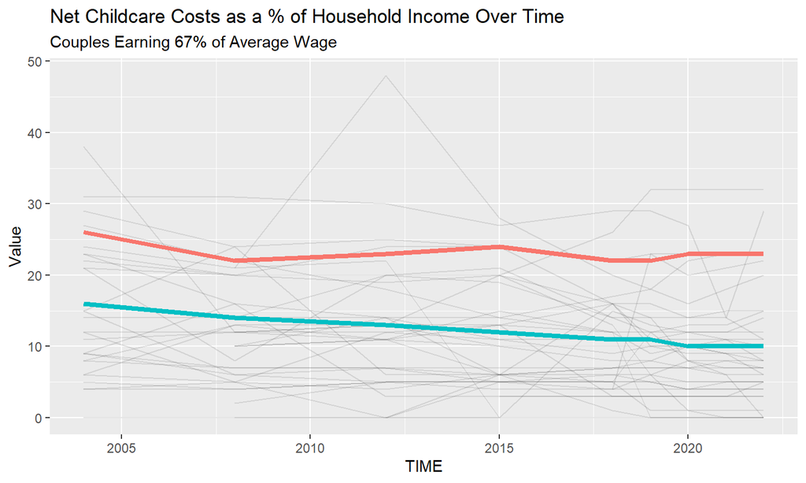

## Background & Context

### Policy History

- Story of childcare policy in England has been one of consistent expansion over past 25 years.
- Table below shows major measures implemented that affect England.
- Policies have typically aimed at expanded free hours entitlement coupled with targeted support for low-earners.
- Source: Adapted and updated from Economic Policy Institute - *The Impact of Recent Government Policies on Early Years Provision* (Akhal, 2019)

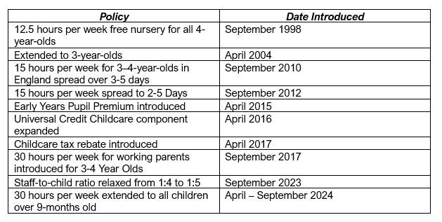

## Specific Policy

- I look specifically at the 2017 expansion of childcare entitlement from 15 hours per week to 30 hours per week.
- Policy intended to help parents of 3-4-year olds.
- Access to policy is dependent on income (equivalent to 16 hours per week worked at national minimum wage)
- Age of eligibility set by cohorts (see below).

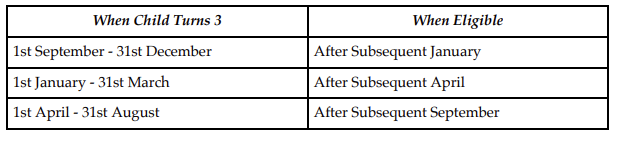

- These cutoffs for access create variation to be exploited.

## Wider Literature Inconsisent on Impact on Labour Supply

### First Forays

- Early theoretical grounding provided by Heckman (1974)
  - Adapts canonical neoclassical model of labour supply for impact of either lump sump subsidy or per-hour worked subsidy.
  - Differential impacts for different categories of mother (i.e. those already working and those not)
  - Generally will increase labour supply but ultimately depends on preferences (MRS).
  - Also calibrates structural econometric model to estimate responses to various subsidy levels.

### Subsequent Findings

- Raft of structurally estimated econometric models during the 1980s and 1990s.
- Wide range of labour supply elasticities produced in US.
  - On extensive margin, ranges from -0.2 (Connolly, 1992) to -0.92 (Anderson and Levine, 1999).
  - On intensive margin, ranges from -0.024 (Ribar, 1995) to -0.78 (Averett, Peters and Waldman, 1997)

## Wider Literature Inconsisent on Impact on Labour Supply

### Later Findings

- After Credibility Revolution during mid-90s - present, emphasis shifts to causal inference methods.
- Typically framed around specific policy interventions and quasi-experimental design:
  - Havnes & Mogestad (2011) analyse long-run impacts from policy interventions in Norway. Find no net increase in maternal labour supply.
  - Nollenberger & Rodriguez-Planas (2015) look into early ’90s reforms in Spain. Find +2.1% extensive margin impact, signif at 10% level.
  - Germany: Bauernschuster & Schlotter (2015) find free kindergarten raised participation by 6 per cent.
  - Germany: Gathmann & Sass (2018) find *introduction* of costs to generate no labour supply response from mothers.
  - UK: Brewer et al. (2021) estimate movement from part-time to full-time childcare (using minimum schooling age) increases participation by 2.1%.
- Inconsistency in labour supply findings mirrored by inconsistency in second-order impacts (crowding out, deadweight loss etc.)

## Data Used

### Description

- I utilise the special licence version of *Understanding Society* (USOC). This is an individual and household longtiduinal survey in the UK covering the years 2009 - 2022.
- This dataset includes a comprehensive and unparalleled range of variables relating to personal characteristics, economic and labour market data, as well as childcare specific information.
- The advantages of using USOC as a datasource is the fact that it removes the need to link or merge with other data sources and potentially lose accuracy of the data.

## Data Used

### Data Overview

Summary Statistics

| Variable | N | Mean | Std. Dev. | Min | Pctl. 25 | Pctl. 75 | Max |
| --- | --- | --- | --- | --- | --- | --- | --- |
| sex_dv | 223123 | 0.55 | 0.5 | 0 | 0 | 1 | 1 |
| intdaty_dv | 223123 | 2014 | 3.4 | 2009 | 2011 | 2017 | 2022 |
| age_dv | 223123 | 41 | 12 | 16 | 32 | 49 | 88 |
| birthy | 223123 | 1971 | 64 | -9 | 1964 | 1982 | 2005 |
| relationship | 223123 | 0.72 | 0.45 | 0 | 0 | 1 | 1 |
| ltsick | 223123 | 0.23 | 0.42 | 0 | 0 | 0 | 1 |
| educat | 223123 | 0.7 | 0.46 | 0 | 0 | 1 | 1 |
| inedorwork | 223123 | 0.99 | 0.1 | 0 | 1 | 1 | 1 |
| ftemp | 223123 | 0.72 | 0.45 | 0 | 0 | 1 | 1 |
| ptemp | 223123 | 0.28 | 0.45 | 0 | 0 | 1 | 1 |
| jbhrs | 223123 | 32 | 11 | 0.1 | 24 | 39 | 98 |
| usecccare | 223123 | 0.14 | 0.34 | 0 | 0 | 0 | 1 |

- Above shows the summary statistics for the overall data set used after initial sampling decisions taken.
- Contains key personal characteristics as well as economic outcomes and childcare-related variables.

## Empirical Strategy

### Treatment

- I identify those treated as those eligible for the free childcare based on the criteria set out by HMG.
- Unfortunately USOC does not contain any specific variables that identify whether individual uses free childcare policy so identification rests on identifying those eligible and impact on aggregate (limitation of design).
  - i.e. testing the impact of the policy rather than testing specifically on those who use policy.
- Replication code for treatment generation in “Analysis_File.R”
- Identifies treated individuals based on interaction between:
  - Child date of birth (requires month of birth).
  - Date of observation being recorded.
  - Eligibility cohort.
  - Parental household income.
- Code a dummy variable for those treated vs. those not.

## Empirical Strategy - Logit Results

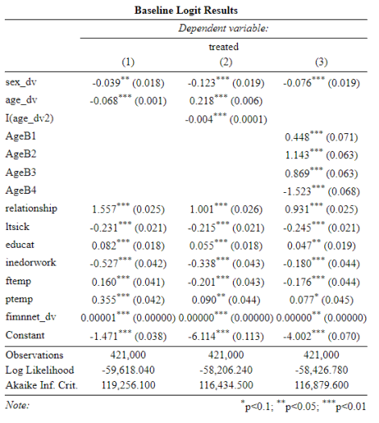

## Empirical Strategy - Probit Results

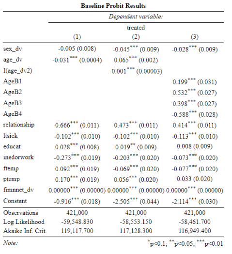

## Empirical Strategy - Matching

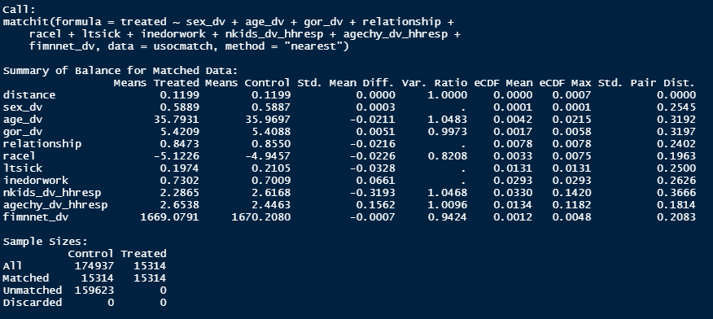

## Empirical Strategy - Matching Summary Stats

Summary Statistics

| Variable | N | Mean | Std. Dev. | Min | Pctl. 25 | Pctl. 75 | Max |
| --- | --- | --- | --- | --- | --- | --- | --- |
| treated | 30628 | 0.5 | 0.5 | 0 | 0 | 1 | 1 |
| sex_dv | 30628 | 0.59 | 0.49 | 0 | 0 | 1 | 1 |
| intdaty_dv | 30628 | 2014 | 3.3 | 2009 | 2011 | 2016 | 2022 |
| age_dv | 30628 | 36 | 8.3 | 16 | 31 | 40 | 89 |
| birthy | 30628 | 1977 | 46 | -9 | 1973 | 1983 | 2004 |
| relationship | 30628 | 0.85 | 0.36 | 0 | 1 | 1 | 1 |
| ltsick | 30628 | 0.2 | 0.4 | 0 | 0 | 0 | 1 |
| educat | 30628 | 0.65 | 0.48 | 0 | 0 | 1 | 1 |
| inedorwork | 30628 | 0.72 | 0.45 | 0 | 0 | 1 | 1 |
| ftemp | 30628 | 0.47 | 0.5 | 0 | 0 | 1 | 1 |
| ptemp | 30628 | 0.22 | 0.41 | 0 | 0 | 0 | 1 |
| jbhrs | 30628 | 16 | 21 | -8 | -8 | 37 | 98 |
| usecccare | 30628 | 0.29 | 0.46 | 0 | 0 | 1 | 1 |

## Results

### Initial Findings

[output not shown]

## Results

### Discussion

- In all 3 cases there does not appear to have been any response to the 2017 expansion.
- Coefficient values in all cases are low.
- No statistically significant effect whatsoever.
- While early stages - this is comfortingly not a complete outlier in comparison to other estimates.
- Nevertheless, does pose questions why there are differences between these findings and those of Brewer et al. (2021) who also look at UK-context *and* at change between PT and FT care but do find a response.
- What could be responsible? What would next steps be?

## Conclusion and Next Steps

### Critical Reflection on Results

- These are evidently a very tentative first-pass of results.
- Difference between these results and Brewer et al. (2021) could be driven by personal characteristics of those treated.
  - In their case looking at parents of children entering primary school.
  - In this case looking at parents of 3-year olds.
  - Descriptive data does suggest a secular trend towards more working as children age, but probably not enough to explain *all* of the difference here.

### Practical Next Steps

- Lots of room for QA and robustness checks.
  - Limited time to conduct sweeps for errors. Some obvious ones already identified (use 2010 rather than 2009 as beginning date).
- Robustness checks (placebo effects, pre-trends etc.)
- Expanding variables of interest to second-order effects.
  - Crowding out, distributional impacts etc.

## Conclusion and Next Steps (cont.)

### Methodological Concerns

- Large literature over the past 2 years relating to DiD.
- Heterogenous timing effects.
- Heterogenous treatment groups.
- Still considering most appropriate estimator from that literature to incorporate.

### Still…

- More than likely that I’ve omitted some concerns or not thought of things.
- Very open to suggestions!

## …And finally…

### Plans for 2nd chapter

- Already ramping up plans for primary data collection.
- Intending to webscrape childcare.co.uk for pricing data.
- Would present a wealth of options for further analysis.
  - e.g. impact of staff-to-child ratios relaxing in September 2023.
  - e.g. impact of further expansion in 2024.
- Unknown number of profiles on website - but estimated sample size per 24 hour webcrawl would result in ~17,000 observations.

[figure not shown]